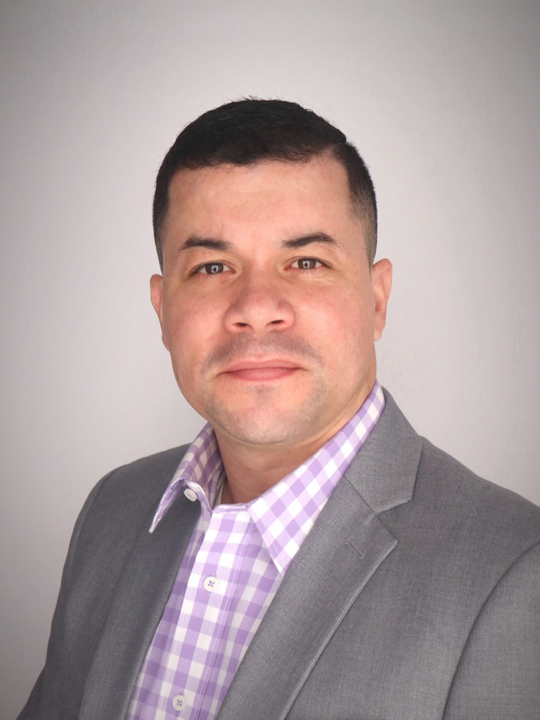

# Oscar Cardec

Email Resume

## Welcome to my Portfolio!

### Bio

Lead Data Scientist combining 20+ years of national security and military leadership with 8 years of specialized experience in data science, full-stack machine learning pipelines, and Generative AI. Proven record of orchestrating cross-functional data engineering initiatives for the DoD, deploying Palantir solutions and cloud analytics ecosystems, and translating complex operational challenges into actionable decision-making tools. Active Security Clearance. Security+ Certified.

### Education

University of Maryland, Global Campus - MS in Data Analytics (MSDA)  
American Military University - BS in Information Technology Management  
Community College of the Air Force - AS in Intelligence Studies & Technology

### Experience

**ManTech** | Lead Data Scientist | Sep 2024 - Present

**WTI** | R&D, Data Strategist | Jul 2023 - Sep 2024

**GovCIO** | Data Scientist & ML Specialist | Feb 2023 - Jul 2023

**Deloitte & Touché, LLC** | Data Scientist | Apr 2021 - Feb 2023

**Accenture Federal Services** | Data Scientist Intern | Oct 2020 - Mar 2021

**US Air Force** | Manager, Intelligence Analyst | 2013 - 2020

**US Air Force** | Information Manager & Database Administrator | 2007 - 2013

**US Air Force** | Aerospace Maintenance Craftsman | 2000 - 2007